# Lab 4: Childcare Costs in California

Author

Aiden Rodriguez

## The Data

**0. Load the appropriate libraries and the data.**

```r
library(tidyverse)
library(dplyr)
```

**1. Briefly describe the data (~ 4 sentences). What information does it contain?**

The childcare costs csv contains a lot of information about various rates, such as unemployment rate, labor force participation rate, poverty rates, population counts, etc. It’s sorted by county and year, and most importantly contains information on median price charged for center based care and family childcare. The counties data has an ID that can be linked to the previous dataset that has the full county name, state, and state abreviation. Finally, the tax_rev csv has data on taxes such as property tax and sales and use tax, and it seems to be linked to the counties dataset on the county name.

## California Childcare Costs

**2. Let’s focus only on California. Create a `ca_childcare` dataset containing (1) county information and (2) all information from the `childcare_costs` dataset.**

**a. Sketch a plan for completing this task and include an image of the sketch or write out the steps of your plan in plain english (not with function names!). You should do all of this within one pipeline**

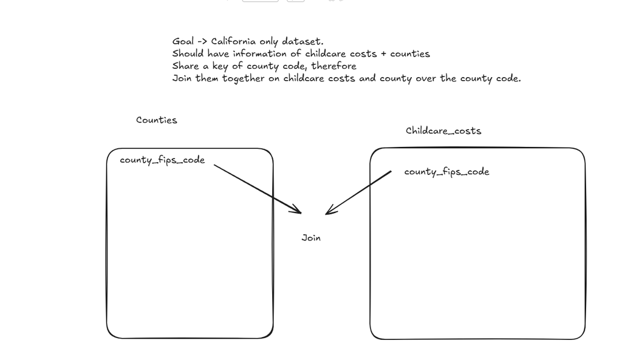

My plan for the Question

**b. Implement/code your game plan to create the dataset of childcare costs in California.** *Checkpoint: There are 58 counties in CA and 11 years in the dataset. Therefore, your new dataset should have 638 observations.*

```r
ca_childcare <- counties |>
  filter(state_name == "California") |>
  inner_join(childcare_costs, by = "county_fips_code")
```

**3. Now, lets add the tax revenue information to the `ca_childcare` dataset. Add the data from `tax_rev` for the counties and years that are already in the `ca_childcare` data. Overwrite the old `ca_childcare` data with this dataset.** *Checkpoint: you are just adding columns here, so your new dataset should still have 638 observations*

```r
ca_childcare <- ca_childcare |>
  left_join(tax_rev, join_by(county_name == entity_name, study_year == year))
```

**4. Using a function from the `forcats` package, complete the code below to create a new variable where each county is categorized into one of the [10 Census regions](https://census.ca.gov/regions/) in California. Use the Region description (from the plot), not the Region number (e.g. “Superior California” not “1”).** The code below will help you get started.

```r
# defining 10 census regions

superior_counties <- c("Butte","Colusa","El Dorado",
                       "Glenn","Lassen","Modoc",
                       "Nevada","Placer","Plumas",
                       "Sacramento","Shasta","Sierra","Siskiyou",
                       "Sutter","Tehama","Yolo","Yuba")

north_coast_counties <- c("Del Norte","Humboldt","Lake",
                          "Mendocino","Napa","Sonoma","Trinity")

san_fran_counties <- c("Alameda","Contra Costa","Marin",
                       "San Francisco","San Mateo","Santa Clara",
                       "Solano")

n_san_joaquin_counties <- c("Alpine","Amador","Calaveras","Madera",
                            "Mariposa","Merced","Mono","San Joaquin",
                            "Stanislaus","Tuolumne")

central_coast_counties <- c("Monterey","San Benito","San Luis Obispo",
                            "Santa Barbara","Santa Cruz","Ventura")

s_san_joaquin_counties <- c("Fresno","Inyo","Kern","Kings","Tulare")

inland_counties <- c("Riverside","San Bernardino")

la_county <- "Los Angeles"

orange_county  <- "Orange"

san_diego_imperial_counties <- c("Imperial","San Diego")
```

```r
ca_childcare <- ca_childcare |>
  mutate(
    county_name = str_remove(county_name, " County"),
    region = fct_collapse(
      as.factor(county_name),
      "Superior California" = superior_counties,
      "North Coast" = north_coast_counties,
      "San Francisco Counties" = san_fran_counties,
      "North San Joaquin Valley" = n_san_joaquin_counties,
      "Central Coast" = central_coast_counties,
      "South San Joaquin Valley" = s_san_joaquin_counties,
      "Inland Counties" = inland_counties,
      "Los Angeles" = la_county,
      "Orange County" = orange_county,
      "San Diego and Imperial" = san_diego_imperial_counties
    )
  )
#glimpse(ca_childcare)
```

**5. Let’s consider the median household income of each region, and how that income has changed over time. Create a table with ten rows, one for each region, and three columns, 2008 income, 2018 income, and region. The cells should contain the `median()` of the median household income (expressed in 2018 dollars) of the `region` and the `study_year`. Order the rows by 2018 values from highest income to lowest income.**

```r
median_table <- ca_childcare |>
  filter(study_year %in% c(2008, 2018)) |>
  group_by(region, study_year) |>
  summarize(
    mhi_2018 = median(mhi_2018),
    .groups = "drop") |>
  pivot_wider(
    names_from = study_year,
    values_from = mhi_2018,
    names_prefix = "income ") |>
  arrange(desc(`income 2018`))
```

[output not shown]

**6. Which California `region` had the lowest `median` full-time median weekly price for center-based childcare for infants in 2018? Does this `region` correspond to the `region` with the lowest `median` income in 2018 that you found in Q4?**

```r
childcare_table <- ca_childcare |>
  filter(study_year == 2018) |>
  group_by(region) |>
  summarize(
    mc_infant = median(mc_infant),
    .groups = "drop") |>
  filter(mc_infant == min(mc_infant))

childcare_table
```

```
# A tibble: 1 × 2
  region              mc_infant
  <fct>                   <dbl>
1 Superior California      215.
```

**7. The following plot shows, for all ten regions, the change over time of the full-time median price for center-based childcare for infants, toddlers, and preschoolers. Recreate the plot. You do not have to replicate the exact colors or theme, but your plot should have the same content, including the order of the facets and legend, reader-friendly labels, axes breaks, and a loess smoother.**

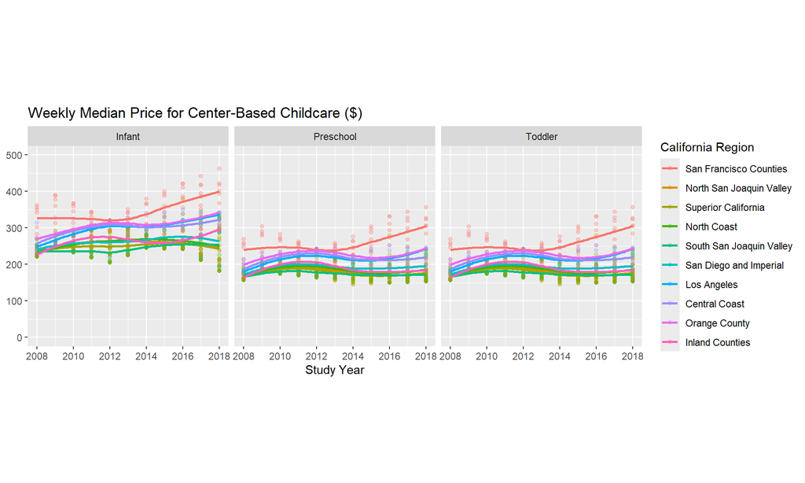

```r
ca_childcare |>
  select(mc_infant, mc_toddler, mc_preschool, study_year, region) |>
  pivot_longer(
    cols = c(mc_infant, mc_toddler, mc_preschool),
    names_to = "care_type",
    values_to = "cost") |>
  mutate(
    care_type = recode(care_type,
      mc_infant = "Infant",
      mc_toddler = "Toddler",
      mc_preschool = "Preschool"),
  ) |>
  ggplot(aes(x = study_year,
             y = cost,
             color = region)) +
  geom_point(alpha = 0.3) +
  geom_smooth(se = FALSE,
              linewidth = 1) +
  facet_wrap(~care_type) +
  scale_y_continuous(limits = c(0, 500)) +
  scale_x_continuous(breaks = seq(2008, 2018, by = 2)) +
  labs(
    x = "Study Year",
    y = NULL,
    color = "California Region",
    title = "Weekly Median Price for Center-Based Childcare ($)"
  ) +
  theme(aspect.ratio = 1)
```

## Median Household Income vs. Childcare Costs for Infants

**8. Create a scatterplot showing the relationship between median household income (expressed in 2018 dollars) and the full-time median weekly price charged for center-based childcare for an infant in California. Overlay a linear regression line (lm) to show the trend.**

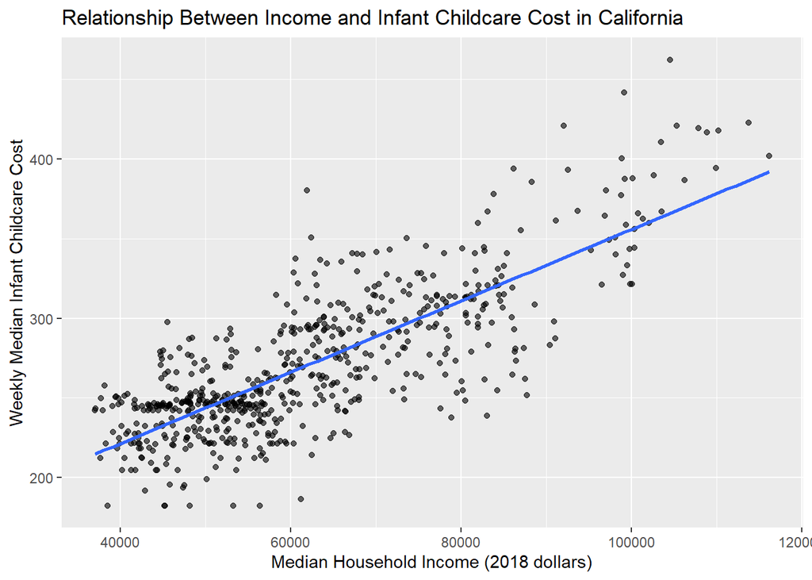

```r
ca_childcare |>
  ggplot(aes(
    x = mhi_2018,
    y = mc_infant)) +
  geom_point(alpha = 0.6) +
  geom_smooth(method = "lm", se = FALSE) +
  labs(
    x = "Median Household Income (2018 dollars)",
    y = "Weekly Median Infant Childcare Cost",
    title = "Relationship Between Income and Infant Childcare Cost in California")
```

**9. Look up the documentation for `lm()` and fit a linear regression model to the relationship shown in your plot above (recall: $y = mx+b$). Identify the coefficient estimates from the model.**

```r
reg_mod1 <- lm(mc_infant ~ mhi_2018, data = ca_childcare)
summary(reg_mod1)
```

```
Call:
lm(formula = mc_infant ~ mhi_2018, data = ca_childcare)

Residuals:
    Min      1Q  Median      3Q     Max
-82.407 -15.606   0.097  15.999 110.026

Coefficients:
             Estimate Std. Error t value Pr(>|t|)
(Intercept) 1.317e+02  4.321e+00   30.49   <2e-16 ***
mhi_2018    2.241e-03  6.737e-05   33.26   <2e-16 ***
---
Signif. codes:  0 '***' 0.001 '**' 0.01 '*' 0.05 '.' 0.1 ' ' 1

Residual standard error: 27.48 on 636 degrees of freedom
Multiple R-squared:  0.635, Adjusted R-squared:  0.6344
F-statistic:  1106 on 1 and 636 DF,  p-value: < 2.2e-16
```

**10. Do you have evidence to conclude there is a relationship between the median household income and the median weekly cost of center-based childcare for infants in California? Cite values from your output for support.**

Yes, there is a positive relationship. The slope is positive, and as income increases so does the cost. The p-value is very small, confirming that this is accurate.The R^2 value explains 63.5% of the variability in the childcare costs, which means there is a solid relationship.

## Open-Ended Analysis

**11. Posit and investigate a research question involving at least two variables in this dataset. Present exactly one table of summary statistics and one plot that helps to address your research question.**

Research Question: How does the percentage of single-mother households with children under 6 relate to childcare costs?

```r
ca_childcare <- ca_childcare |>
  mutate(pct_single_mother = h_under6_single_m / households)

summary_table <- ca_childcare |>
  group_by(region) |>
  summarize(
    pct_single_mother = mean(pct_single_mother),
    infant_cost = median(mc_infant),
    toddler_cost = median(mc_toddler),
    preschool_cost = median(mc_preschool),
    .groups = "drop") |>
  arrange(desc(pct_single_mother))

summary_table
```

```
# A tibble: 10 × 5
   region              pct_single_mother infant_cost toddler_cost preschool_cost
   <fct>                           <dbl>       <dbl>        <dbl>          <dbl>
 1 San Diego and Impe…            0.0889        251.         182.           182.
 2 South San Joaquin …            0.0869        245.         173.           173.
 3 Inland Counties                0.0768        264.         187.           187.
 4 Los Angeles                    0.0646        304.         216.           216.
 5 Central Coast                  0.0539        301.         214.           214.
 6 North San Joaquin …            0.0497        249.         177.           177.
 7 North Coast                    0.0453        250.         179.           179.
 8 Orange County                  0.0423        312.         225.           225.
 9 Superior California            0.0418        246.         175.           175.
10 San Francisco Coun…            0.0362        344.         254            254
```

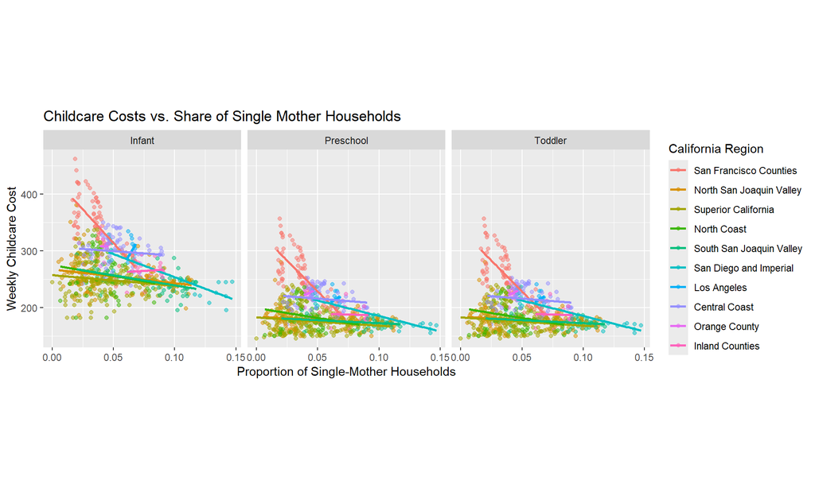

```r
ca_childcare |>
  pivot_longer(
    cols = c(mc_infant, mc_toddler, mc_preschool),
    names_to = "care_type",
    values_to = "cost") |>
  mutate(
    care_type = recode(care_type,
      mc_infant = "Infant",
      mc_toddler = "Toddler",
      mc_preschool = "Preschool")) |>
  ggplot(aes(x = pct_single_mother, y = cost, color = region)) +
  geom_point(alpha = 0.5, size = 1.5) +
  geom_smooth(method = "lm",
              se = FALSE,
              linewidth = 1) +
  facet_wrap(~care_type) +
  labs(
    x = "Proportion of Single-Mother Households",
    y = "Weekly Childcare Cost",
    color = "California Region",
    title = "Childcare Costs vs. Share of Single Mother Households") +
  theme(aspect.ratio = 1)
```

**Table Description**

It seems like the negative relationship may be due to other factors than the single mother percentage, and as is known, correlation does not equal causation. There are exceptions in the Central Coast and Los Angeles as previously stated, and there seems to be more to the data that doesn’t confirm a strong relationship between these variables, despite there being some evidence.